This document explains how to use R to get colocalized environmental data for a cruise named “MGL1704” provided by Francois Ribalet with the Ambrust lab. Some of the material comes directly from here: https://github.com/armbrustlab/popcycle/wiki/SeaFlow-data-analysis-tutorial.

# Getting the cruise trajectory (skim)

From the MGL1704 cruise, we can load a table from the DB file “MGL1704/MGL1704.db” that contains cruise-level data:

```r
## RETRIEVE CRUISE-LEVEL DATA
path <- "~/Desktop/"
cruise <- c("MGL1704")
db <- paste0(path, cruise, "/", cruise, ".db")
sfl <- get.sfl.table(db)
sfl <-  sfl[-nrow(sfl),]
head(sfl)
```

```
##                                 file                      date
## 1 2017_146/2017-05-26T22-34-53+00-00 2017-05-26T22:34:53+00:00
## 2 2017_146/2017-05-26T22-37-53+00-00 2017-05-26T22:37:53+00:00
## 3 2017_146/2017-05-26T22-40-53+00-00 2017-05-26T22:40:53+00:00
## 4 2017_146/2017-05-26T22-43-54+00-00 2017-05-26T22:43:54+00:00
## 5 2017_146/2017-05-26T22-46-54+00-00 2017-05-26T22:46:54+00:00
## 6 2017_146/2017-05-26T22-49-54+00-00 2017-05-26T22:49:54+00:00
##   file_duration     lat       lon conductivity salinity ocean_tmp par
## 1       180.090 21.3164 -157.8767         0.92   5.0774   25.6024  NA
## 2       180.071 21.3164 -157.8767         0.92   5.0774   25.6024  NA
## 3       180.068 21.3164 -157.8767         0.92   5.0774   25.6024  NA
## 4       180.082 21.3164 -157.8767         0.92   5.0774   25.6024  NA
## 5       180.098 21.3164 -157.8767         0.92   5.0774   25.6024  NA
## 6       180.087 21.3164 -157.8767         0.92   5.0774   25.6024  NA
##   bulk_red stream_pressure event_rate
## 1  72.3429           10.21    5214.55
## 2  73.4761           12.00    3284.29
## 3  73.4761           12.00    3305.83
## 4  73.4761           12.00    3287.42
## 5  73.4761           12.00    3263.28
## 6  73.4761           12.00    3261.74
```

```r
## Get all the cytograms that are "robust"
out = get.outlier.table(db)

## Match the dates,
dates = sapply(out[,1],function(a){
  dt = substr(a,10,19)
  tm = substr(a,21,100)
  tm = str_replace_all(tm, "-", ":")
  paste0(dt, "T", tm)
})

## Isolate our attention to only robust /dates/, according to the names of the images.
all.robust = which(out$flag==0)#
sfl = sfl[-all.robust,]

## There is also one NA value, don't know why.
npoints = nrow(sfl)  ## npoitns=100
sfl = sfl[-which(is.na(sfl[1:npoints,"lon"])),]
```

From this, we create a CSV file containing a table which contains three data columns ‘lat’, ‘lon’ and ‘date’. We will use these as target triplets in space and time, for colocalization.

```r
csvtable = sfl[,c("date", "lat", "lon")]
csvfilename = "MGL1704.csv"

## convert date to cmap's desired format.
dates = csvtable[,1]
newdates = sapply(dates, function(mydate){
  dt = substr(mydate, 1,10)
  tm = substr(mydate, 12,19)
  paste0(dt, "T", tm)
})
csvtable[,1] = newdates
names(csvtable)[1] = "time"

## Date
write.csv(csvtable, file=file.path(outputdir, csvfilename), row.names=FALSE)
head(csvtable)
```

```
##                  time     lat       lon
## 1 2017-05-26T22:34:53 21.3164 -157.8767
## 2 2017-05-26T22:37:53 21.3164 -157.8767
## 3 2017-05-26T22:40:53 21.3164 -157.8767
## 4 2017-05-26T22:43:54 21.3164 -157.8767
## 5 2017-05-26T22:46:54 21.3164 -157.8767
## 6 2017-05-26T22:49:54 21.3164 -157.8767
```

```r
dim(csvtable)
```

```
## [1] 3201    3
```

This CSV table can be replaced with a manually created table of the same format, or a “virtual cruise” obtained through the Simons CMAP GUI program.

# Taking a hint from python for writing the R functionality

The python script to colocalize is as follows:

```python
from opedia import colocalize as COL

DB = False                            # < True > if source data exists in the database. < 0 > if the source data set is a spreadsheet file on disk.
source = '~/Desktop/MGL1704.csv'            # the source table name (or full filename)
temporalTolerance = 1                # colocalizer temporal tolerance (+/- days)
latTolerance = 0.3                   # colocalizer meridional tolerance (+/- degrees)
lonTolerance = 0.3                   # colocalizer zonal tolerance (+/- degrees)
depthTolerance = 5                   # colocalizer depth tolerance (+/- meters)
tables = ['tblSST_AVHRR_OI_NRT', 'tblPisces_NRT', 'tblDarwin_Plankton_Climatology']    # list of varaible table names


variables = ['sst', 'Fe', 'picoeukaryote_c03_darwin_clim']                            # list of variable names
exportPath = './loaded.csv'         # path to save the colocalized data set

COL.matchSource(DB, source, temporalTolerance, latTolerance, lonTolerance, depthTolerance, tables, variables, exportPath)
```

Put simply, the python function `COL.matchsource()` takes in

1. A CSV file containing date/lon/lat (e.g. “MGL1704.csv”).
2. A set of “tolerance” variables for colocalization (e.g. temporalTolerance).
3. Tables (data sources) to look into.
4. Variables within those tables.
5. Output file name (e.g. “./loaded.csv”).

Then, it loops over the tables and variables, and for each triplet (lat/lon/time), it issues individual queries to obtain a sub-dataset correposponding to the “rectangle”, or vicinity of the target triplet. From each sub-dataset, it calculates the mean and standard deviation.

We’ll replicate this in our R implementation.

# The R function

The R function `colocalize` looks like this (in `./colocalize.R`):

```r
##' Mimics the matchSource() function in python.
##' @param table.name Table name
##' @param sel.vars A vector  of variable  names in this  table that are  to be
##'   queried
##' @param latMargin Latitude margin.
##' @param lonMargin Longitude margin.
##' @param timeMargin Time margin.
##' @param source The  file name  of the  csv source  file that  contains the
##'   lat/lon/date triplets.
matchSource_onetable <- function(con, source, table.name, sel.vars,
                        latMargin, lonMargin, timeMargin,
                        orderby=NULL
                        ){

  ## Read in source table
  source.table = read.csv(source)
  ntriplets = nrow(source.table)

  ## Empty data frame to fill in
  DF = data.frame(matrix(nrow=ntriplets)[,-1])

  DF[["lat"]] = source.table[,"lat"]
  DF[["lon"]] = source.table[,"lon"]
  DF[["time"]] = source.table[,"time"]


  ## TODO Remember to add depth query
  ## if not 'depth' in srcDF.columns:
  ##     srcDF['depth'] = 0

  ## For each variable in "variables",
  ## TODO: loop over tables as well, or wrap around this.
  for(sel.var in sel.vars){
    means = rep(NA, ntriplets)
    stds = rep(NA, ntriplets)
    for(itriplet in 1:ntriplets){
      printprogress(itriplet,ntriplets)
      lat = source.table[itriplet,"lat"]
      lon = source.table[itriplet,"lon"]
      dt = source.table[itriplet, "time"]

      ## Query that subtable:
      range.var = return_range(lat, lon, dt, latMargin, lonMargin, timeMargin)
      tbl.subset = getTableData(con, table.name, sel.var, range.var, orderby)

      ## Aggregate it (for now, only calculating means)
      if(nrow(tbl.subset)==0){
        means[itriplet] = NA
      } else {
        values = tbl.subset[[sel.var]]
        means[itriplet] = mean(values, na.rm=TRUE) ## Removing the NAs
        stds[itriplet] = sd(values, na.rm=TRUE) ## Removing the NAs
      }
    }
    DF[[sel.var]] = means
    DF[[paste0(sel.var, "-std")]] = stds
  }
  return(DF)
}
```

# Some specific steps required (skip, not important)

Here are the specifics. First, take the data catalog downloaded from “catalog.py” per directions here https://cmap.readthedocs.io/en/latest/catalog/catalog.html. Assume that has been done and “catalog.csv” exists. We’ll isolate our attention to just the table names and variable names therein.

```r
## Read tablenames and variablenames from the catalog
filedir = "/home/shyun/Dropbox/research/usc/flow-cytometry/data"
filename = "catalog.csv"
tab = read.csv(file.path(filedir, filename))
tab = tab[,c("Variable", "Table_Name")]
tab = as.matrix(tab)

## Define table names and variable names for further use
tablenames = sapply(unique(tab[,"Table_Name"]), toString)
variablenames = lapply(tablenames, function(tablename){
  sapply(tab[which(tab[,"Table_Name"]==tablename), "Variable"], toString)
})
names(variablenames) = tablenames
```

From this two-column catalog, we have the (table name – variable name) pairs in each row. Now, we will find which tables have lat/lon/time overlap with our desired triplets (“source”), to isolate our attention to fewer tables. We then further write these into a csv file.

```r
## Take each table's range, compare with source's range.
load(file=file.path("./", "tables-range.Rdata"))
relevant.tablenames = match.ranges(range.tables, source)
elevant.tablenames = relevant.tablenames[-5] ## Excluding the simulated phytoplankton species
print(relevant.tablenames)
```

```
## [1] "tblAltimetry_REP"        "tblWind_NRT"
## [3] "tblSST_AVHRR_OI_NRT"     "tblPisces_NRT"
## [5] "tblSeaFlow"              "tblHOT_Macrozooplankton"
## [7] "tblArgoMerge_REP"        "tblSSS_NRT"
## [9] "tblModis_AOD_REP"
```

# Example of results

Now, run the colocalization on all relevant tables whose names are in `relevant.tablenames`, as follows:

```r
## Setup
con = DBI::dbConnect(odbc::odbc(), DSN="CMAP-MSSQL",UID="ArmLab",PWD="ArmLab2018")
source = './MGL1704.csv'
latMargin = 0.3
lonMargin = 0.3
timeMargin = 1

## For each relevant table, query the variables, and see if /anything/ comes out
## of it.
for(ii in 1:length(relevant.tablenames)){
  tablename = relevant.tablenames[ii]
  res = matchSource_onetable(con, source, tablename, variablenames[[tablename]],
                             latMargin, lonMargin,
                             timeMargin)
  save(res, file=file.path(outputdir,
                           paste0("res-", tablename, ".Rdata")))
}
```

The results look like this, for a given table and all variables therein (in this case, only one).

```r
tablename = "tblSST_AVHRR_OI_NRT"
ichunk = 1
load(file=file.path(outputdir,
                    paste0("res-", tablename, "-chunk-", ichunk, ".Rdata")))
print(head(res[,-5], 10))
```

```
##        lat       lon                time      sst
## 1  21.3164 -157.8767 2017-05-26T22:34:53 26.18166
## 2  21.3164 -157.8767 2017-05-26T22:37:53 26.18166
## 3  21.3164 -157.8767 2017-05-26T22:40:53 26.18166
## 4  21.3164 -157.8767 2017-05-26T22:43:54 26.18166
## 5  21.3164 -157.8767 2017-05-26T22:46:54 26.18166
## 6  21.3164 -157.8767 2017-05-26T22:49:54 26.18166
## 7  21.3164 -157.8767 2017-05-26T22:52:54 26.18166
## 8  21.3164 -157.8767 2017-05-26T22:55:54 26.18166
## 9  21.3164 -157.8767 2017-05-26T22:58:55 26.18166
## 10 21.3164 -157.8767 2017-05-26T23:01:55 26.18166
```

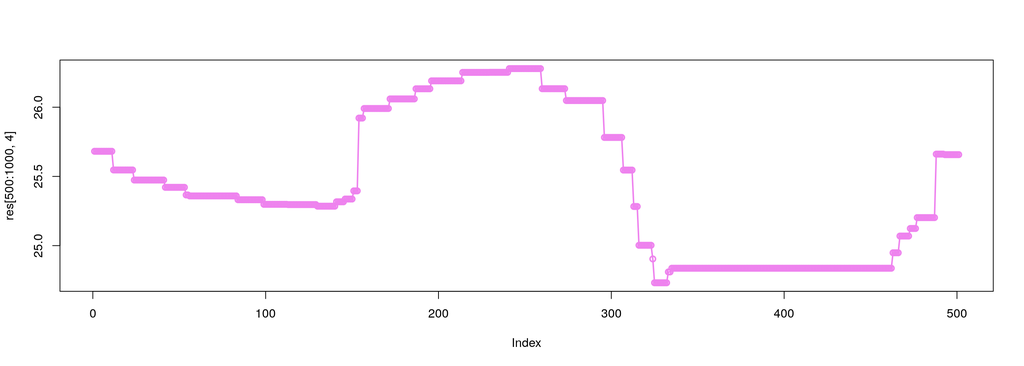

```r
plot(res[500:1000,4], type='o', lwd=2, col='violet')
```

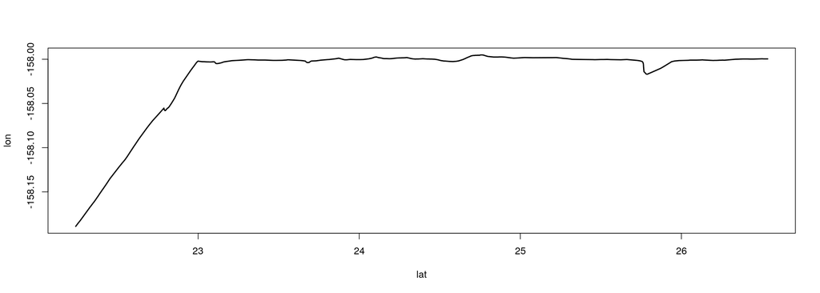

```r
plot(res[500:1000,1:2], type='l', lwd=2, col='black')
```

```r
## Setup
source = './MGL1704.csv'
latMargin = 0.3
lonMargin = 0.3
timeMargin = 1
tablename = "tblSST_AVHRR_OI_NRT"
variablename = "sst"

## For the desired table, query a variable therein
res = matchSource_onetable(con, source, tablename, variablename,
                           latMargin, lonMargin, timeMargin)
```